# Notebook wee5

Bùi Khánh Duy

2023-03-29

## Bài 1

```r
X1 <- rnorm(1000, 0, sqrt(1)) # Sinh ra nn 1000 gt của x1
X2 <- rnorm(1000, 0, sqrt(1)) # Sinh ra nn 1000 gt của x1
```

Để vẽ ellipse -> phải cài đặt thư viện

```r
# install.packages("ellipse")
library(ellipse)
```

Gộp X1 và X2 thành 1 data frame.

```r
X <- data.frame(X1, X2)
head(X)
```

```
##           X1         X2
## 1 -1.3623063 -0.4200308
## 2  1.3514012  0.1838934
## 3  1.2704393 -1.0237100
## 4 -0.5383215 -0.9789109
## 5  0.6523820  0.7337295
## 6 -0.5169770 -0.4825025
```

```r
S = cov(X) # Ma trận hiệp phương sai
S
```

```
##            X1         X2
## X1 0.92599867 0.04825438
## X2 0.04825438 0.92760050
```

```r
cm = colMeans(X)
cm
```

```
##           X1           X2
##  0.001963612 -0.009897295
```

Vẽ đồ thị

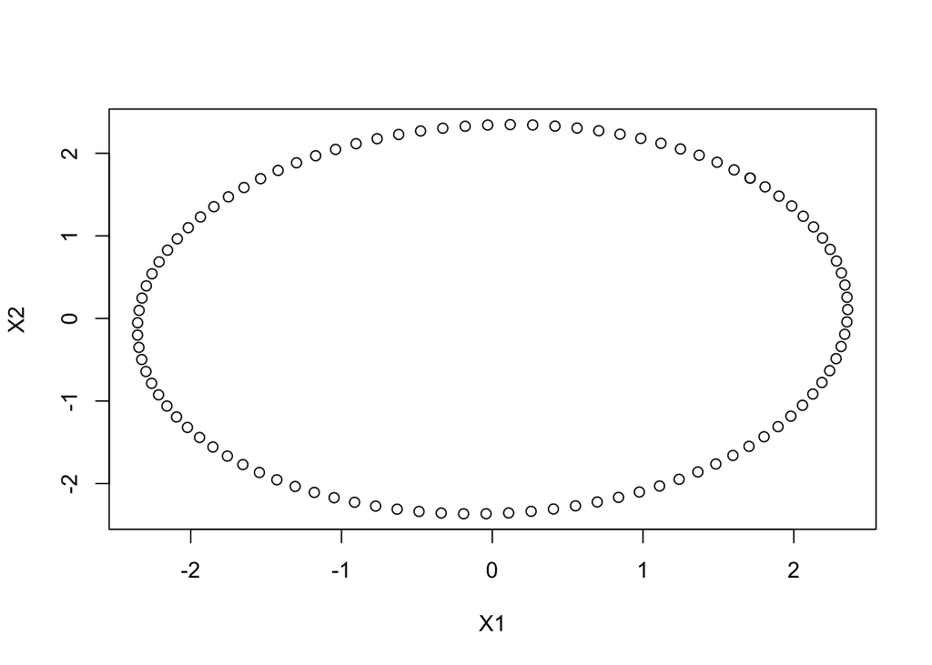

```r
elip = ellipse(S, centre = cm)
plot(elip)
```

Toạ độ tâm của ellipse là kì vọng mẫu

## Bài 2:

Cho trước ma trận hiệp phương sai và kỳ vọng mẫu. Sinh ngẫu nhiên 1000 giá trị của vecto ngẫu nhiên tương ứng. Kiểm định xem từng biến trong vectơ ngẫu nhiên có phân bố chuẩn 1-chiều không?

```r
S = matrix(c(2,0,0,3), nrow=2)
S
```

```
##      [,1] [,2]
## [1,]    2    0
## [2,]    0    3
```

```r
cm = c(0,1)
```

Dùng data có sẵn từ thư viện MASS

```r
# install.packages("MASS")
library(MASS)

X = mvrnorm(1000, cm, S)
head(X)
```

```
##            [,1]       [,2]
## [1,]  1.5546633 -1.0785801
## [2,] -2.2263300 -0.2656136
## [3,]  0.4198744 -0.2823615
## [4,] -3.0808790  0.9151344
## [5,] -1.9456704  2.5526643
## [6,] -0.6187714 -0.9588370
```

```r
shapiro.test(X[,1])
```

```
##
##  Shapiro-Wilk normality test
##
## data:  X[, 1]
## W = 0.99777, p-value = 0.2007
```

# Mô hình hồi quy tuyến tính

$$\begin{aligned}
Y &= a_0 + \varepsilon\\
Y &= a_0 + a_i X_i + \varepsilon\\
Y &= a_0 + a_iX_i + a_jX_j + \varepsilon\\
&... \\
Y &= a_0 + a_iX_i + a_jX_j + ... + a_k X_k + \varepsilon (\leftarrow
Step backward)
\end{aligned}$$

Sử dụng chỉ số AIC để xét mô hình phù hợp. AIC nhỏ nhất <=> Mô hình phù hợp nhất Ví dụ ở bước 2 thứ đã thoả mãn AIC min -> dừng lại.

=>

- Đưa ra mô hình HQTT/ƯL của các hệ số hồi quy
- Kiểm định hệ số: $H_0: a_1 = 0$ vs $H_1: a_1 ≠ 0$
- Tìm khoảng tin cậy cho Hệ số hồi quy
- Kiểm định phần dư $\varepsilon = y-\hat {y} \sim N(0, \sigma_2^2)$

Ví dụ

```r
library("datasets")
only = lm(mpg ~ 1, data = mtcars) # Biểu diễn HQTT của mpg vs chính nó
only
```

```
##
## Call:
## lm(formula = mpg ~ 1, data = mtcars)
##
## Coefficients:
## (Intercept)
##       20.09
```

```r
# mpg = 20.09
two = lm(mpg ~ cyl, data=mtcars) # Biểu diễn HQTT của mpg theo cyl
two
```

```
##
## Call:
## lm(formula = mpg ~ cyl, data = mtcars)
##
## Coefficients:
## (Intercept)          cyl
##      37.885       -2.876
```

```r
two2 = lm(mpg ~ cyl + 0, data=mtcars) # Biểu diễn HQTT của mpg theo cyl mất hệ số tự do
two2
```

```
##
## Call:
## lm(formula = mpg ~ cyl + 0, data = mtcars)
##
## Coefficients:
##  cyl
## 2.79
```

```r
# mpg = 2.79 * cyl

thr = lm(mpg ~ cyl + disp, data = mtcars) # Biểu diễn HQTT của mpg theo cyl và disp
thr$coefficients
```

```
## (Intercept)         cyl        disp
## 34.66099474 -1.58727681 -0.02058363
```

```r
# PTHQTT: mpg = 34.66099474 -1.58727681*cyl -0.02058363*disp

ff = lm(mpg ~ cyl + disp + hp, data = mtcars) # Biểu diễn HQTT của mpg theo cyl, disp và hp
summary(ff)
```

```
##
## Call:
## lm(formula = mpg ~ cyl + disp + hp, data = mtcars)
##
## Residuals:
##     Min      1Q  Median      3Q     Max
## -4.0889 -2.0845 -0.7745  1.3972  6.9183
##
## Coefficients:
##             Estimate Std. Error t value Pr(>|t|)
## (Intercept) 34.18492    2.59078  13.195 1.54e-13 ***
## cyl         -1.22742    0.79728  -1.540   0.1349
## disp        -0.01884    0.01040  -1.811   0.0809 .
## hp          -0.01468    0.01465  -1.002   0.3250
## ---
## Signif. codes:  0 '***' 0.001 '**' 0.01 '*' 0.05 '.' 0.1 ' ' 1
##
## Residual standard error: 3.055 on 28 degrees of freedom
## Multiple R-squared:  0.7679, Adjusted R-squared:  0.743
## F-statistic: 30.88 on 3 and 28 DF,  p-value: 5.054e-09
```

```r
# mpg = a0 + a1*cyl + a2*disp + a3*hp + e
# Ước lượng cho các hệ số trong mô hình hồi quy:
# _h aka \hat
# a0_h = 34.18492, a1_h = -1.22742, a2_h = -0.01884, a3_h = -0.01468
# y_h[i] = mpg_h[i] = a0_h + a1_h*cyl[i] + a2_h*disp[i] + a3_h*hp[i]
# Có sẵn trong quan sát: y[i] = mpg[i]
# Phần dư e[i] = y[i] - y_h[i]
e = ff$residuals # phần dư
```

## Kiểm định phần dư

Kiểm định xem phần dư có tuân theo phân phố ichẩun với giá trị trung bình tuân theo pp chuẩn hay không? H0: e tuân theo pp chuẩn vs H1: e không tuân theo pp chuẩn

```r
shapiro.test(e) # kiểm định theo pp chuẩn
```

```
##
##  Shapiro-Wilk normality test
##
## data:  e
## W = 0.94359, p-value = 0.09469
```

Do p-value = 0.09469 > 0.05 => e tuân theo phân phối chuẩn

Kiểm tra xem phần dư có giá trị trung bình = 0 hay không? H0: E(e) = 0 vs H1: E(e) ≠ 0

```r
t.test(e)
```

```
##
##  One Sample t-test
##
## data:  e
## t = 1.0815e-16, df = 31, p-value = 1
## alternative hypothesis: true mean is not equal to 0
## 95 percent confidence interval:
##  -1.046883  1.046883
## sample estimates:
##    mean of x
## 5.551115e-17
```

Vì p-value = 1 > 0.05 nên chấp nhận H0

Còn nếu e không tuân theo pp chuẩn thì dùng hàm này để kiểm định giá trị trung bình của e

```r
wilcox.test(e)
```

```
##
##  Wilcoxon signed rank exact test
##
## data:  e
## V = 239, p-value = 0.6511
## alternative hypothesis: true location is not equal to 0
```

```r
all = lm(mpg~., data=mtcars) # biểu diễn hqtt của mpg theo tất cả các biến còn lại
summary(all)
```

```
##
## Call:
## lm(formula = mpg ~ ., data = mtcars)
##
## Residuals:
##     Min      1Q  Median      3Q     Max
## -3.4506 -1.6044 -0.1196  1.2193  4.6271
##
## Coefficients:
##             Estimate Std. Error t value Pr(>|t|)
## (Intercept) 12.30337   18.71788   0.657   0.5181
## cyl         -0.11144    1.04502  -0.107   0.9161
## disp         0.01334    0.01786   0.747   0.4635
## hp          -0.02148    0.02177  -0.987   0.3350
## drat         0.78711    1.63537   0.481   0.6353
## wt          -3.71530    1.89441  -1.961   0.0633 .
## qsec         0.82104    0.73084   1.123   0.2739
## vs           0.31776    2.10451   0.151   0.8814
## am           2.52023    2.05665   1.225   0.2340
## gear         0.65541    1.49326   0.439   0.6652
## carb        -0.19942    0.82875  -0.241   0.8122
## ---
## Signif. codes:  0 '***' 0.001 '**' 0.01 '*' 0.05 '.' 0.1 ' ' 1
##
## Residual standard error: 2.65 on 21 degrees of freedom
## Multiple R-squared:  0.869,  Adjusted R-squared:  0.8066
## F-statistic: 13.93 on 10 and 21 DF,  p-value: 3.793e-07
```

```r
summary(ff)
```

```
##
## Call:
## lm(formula = mpg ~ cyl + disp + hp, data = mtcars)
##
## Residuals:
##     Min      1Q  Median      3Q     Max
## -4.0889 -2.0845 -0.7745  1.3972  6.9183
##
## Coefficients:
##             Estimate Std. Error t value Pr(>|t|)
## (Intercept) 34.18492    2.59078  13.195 1.54e-13 ***
## cyl         -1.22742    0.79728  -1.540   0.1349
## disp        -0.01884    0.01040  -1.811   0.0809 .
## hp          -0.01468    0.01465  -1.002   0.3250
## ---
## Signif. codes:  0 '***' 0.001 '**' 0.01 '*' 0.05 '.' 0.1 ' ' 1
##
## Residual standard error: 3.055 on 28 degrees of freedom
## Multiple R-squared:  0.7679, Adjusted R-squared:  0.743
## F-statistic: 30.88 on 3 and 28 DF,  p-value: 5.054e-09
```

Kiểm định xem các hệ số trong mô hình hồi quy có thực sự khác 0 không?
$$mpg = a0 + a1*cyl + a2*disp + a3*hp
+ \varepsilon$$

```r
library(stats)
# step(object, scope, scale, direction, trace)
# object = only/all
# scope = formula(all)/formula(all) - formula(only)
# direction = "forward" / "backward"
# trace = 0
forward = step(object = only, scope = formula(all), direction = "forward", trace = 0)
# Tính toán từ mô hình đơn giản nhất đến mô hình phức tạp nhất
forward$anova
```

```
##    Step Df  Deviance Resid. Df Resid. Dev       AIC
## 1       NA        NA        31  1126.0472 115.94345
## 2  + wt -1 847.72525        30   278.3219  73.21736
## 3 + cyl -1  87.14997        29   191.1720  63.19800
## 4  + hp -1  14.55145        28   176.6205  62.66456
```

- Đầu tiên, tính mô hình mpg = a0 thu được AIC = 115…
- Sau đó, tính toán với mô hình 1 biến: $mpg = a0 + a_i * x_i$ thu được 10 chỉ số AIC tương ứng với 10 biến X_i, chọn AIC nhỏ nhất tương ứng với 10 biến X_i, chọn AIC nhỏ nhất = 73…
- Sau đó, tính toán với mô hình 2 biến: $mpg = a0 + a_1*wt + a_2*x_j$ thu được 9 chỉ số AIC tương ứng với 9 biến X_j, chọn AIC nhỏ nhất = 63…(cyl)
- Sau đó, tính toán với mô hình 3 biến: $mpg = a0 + a_1*wt + a_2*cyl + a_3 * x_l$ thu được 8 chỉ số AIC tương ứng với 8 biến X_j, chọn AIC nhỏ nhất = 62…(hp)

Vì không còn kết quả tốt hơn nữa nên dừng lại.

Đưa ra khoảng tin cậy cho các hệ số trong mô hình hồi quy

```r
confint(forward) # mặc định là 95%
```

```
##                  2.5 %       97.5 %
## (Intercept) 35.0915623 42.412012412
## wt          -4.6839740 -1.649972191
## cyl         -2.0701179  0.186884238
## hp          -0.0423655  0.006289293
```

```r
backward = step(object = all, scope = formula(only), direction = "backward", trace = 0)
backward$anova
```

```
##     Step Df   Deviance Resid. Df Resid. Dev      AIC
## 1        NA         NA        21   147.4944 70.89774
## 2  - cyl  1 0.07987121        22   147.5743 68.91507
## 3   - vs  1 0.26852280        23   147.8428 66.97324
## 4 - carb  1 0.68546077        24   148.5283 65.12126
## 5 - gear  1 1.56497053        25   150.0933 63.45667
## 6 - drat  1 3.34455117        26   153.4378 62.16190
## 7 - disp  1 6.62865369        27   160.0665 61.51530
## 8   - hp  1 9.21946935        28   169.2859 61.30730
```

```r
forward$coefficients
```

```
## (Intercept)          wt         cyl          hp
##  38.7517874  -3.1669731  -0.9416168  -0.0180381
```

```r
backward$coefficients
```

```
## (Intercept)          wt        qsec          am
##    9.617781   -3.916504    1.225886    2.935837
```